# STAA 566 HW 3 - Map

Author

Tiana Stastny

# 2022 Thailand District Population Map

The purpose of this map is to display how population varies across the district regions in Thailand. The data used is from 2022.

## Thailand shape data

The Thailand shape data, which gives the boundary information for various spatial units (province, district, sub-district, etc) can be downloaded from here:

https://data.humdata.org/dataset/cod-ab-tha

Specifically, I used the ‘tha_adm_rtsd_itos_20210121_shp.zip’ file.

District is a subset of province, and it was more interesting to plot the data at the district level, which is found in the ‘tha_admbnda_adm2_rtsd_20220121.shp’ file. The spatial units being displayed in the maps are regional districts.

## Thailand population data for 2022

The Thailand population data came from the same ‘Humanitarian Data Exchange’ (HDX) source:

https://data.humdata.org/dataset/cod-ps-tha

Specifically, I used the ‘tha_admpop_adm2_2022.csv’ file.

## Load libraries

```r
library(tidyverse)
library(rgeos)
library(rgdal)
library(maptools)
library(broom)
library(dplyr)
library(viridis)
library(leaflet)
library(mapview)
library(htmlwidgets)
```

## Load shape data

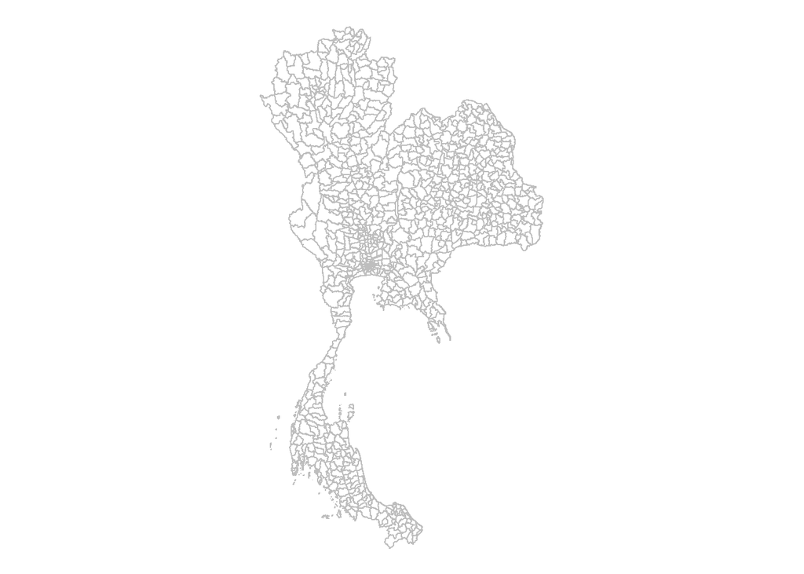

```r
# load data
# thailand_shape_data <- readOGR("C:/Users/tiana/OneDrive/Documents/CSU_STAA_566_Data_Viz/maps-TStas/tha_admbnda_adm2_rtsd_20220121.shp")

thailand_shape_data <- readOGR("C:/Users/tiana/OneDrive/Documents/CSU_STAA_566_Data_Viz/maps-TStas/tha_adm_rtsd_itos_20210121_shp/tha_admbnda_adm2_rtsd_20220121.shp")
# tidying the shape data gets it into a data frame with longitude and latitude
thai_tidy <- tidy(thailand_shape_data, region="ADM2_PCODE")

# plot just districts to begin with
district_plot <- ggplot() + geom_polygon(data = thai_tidy, aes(x = long, y = lat, group = group), fill="white", color="grey")+
  theme_void() +
  coord_map()
district_plot
```

## Load population data

Load the population data.

```r
# read in population data from csv file

thailand_population <- read.csv("C:/Users/tiana/OneDrive/Documents/CSU_STAA_566_Data_Viz/maps-TStas/tha_admpop_adm2_2022.csv")
```

```r
# want the ADM2_EN, ADM2_PCODE and T_TL columns
# Notes on levels of data:
# 0 = country
# 1 = province
# 2 = district  ** we want level 2
# 3 = sub-district
```

Make a new dataframe comprised of the desired columns.

```r
# make new dataframe
district_populations <- data.frame(thailand_population$ADM2_NAME, thailand_population$ADM2_PCODE, thailand_population$T_TL)

# take a look
head(district_populations)
```

```
  thailand_population.ADM2_NAME thailand_population.ADM2_PCODE
1                      Chanuman                         TH3702
2                    Hua Taphan                         TH3706
3                     Lue Amnat                         TH3707
4          Mueang Amnat Charoen                         TH3701
5           Pathum Ratchawongsa                         TH3703
6                         Phana                         TH3704
  thailand_population.T_TL
1                    25704
2                    23228
3                    18235
4                    67475
5                    24735
6                    10830
```

```r
# get dimensions
dim(district_populations)
```

```
[1] 928   3
```

Make a basic bar plot to get high level overview of population values.

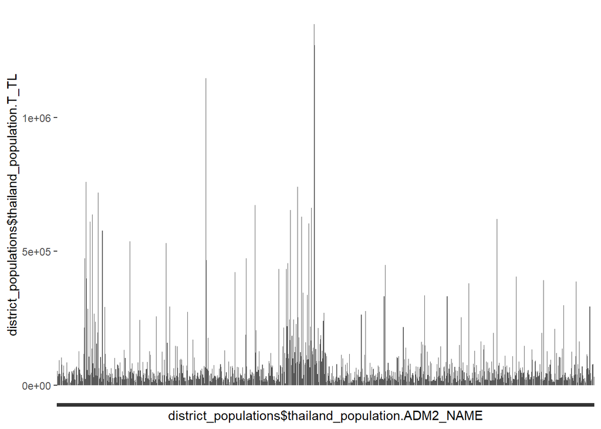

```r
p_bar <- ggplot(data = district_populations, aes(x=district_populations$thailand_population.ADM2_NAME, y=district_populations$thailand_population.T_TL)) +
  geom_bar(stat="identity") +
  theme(axis.text.x=element_blank())  # remove x-axis labels - too messy for now
p_bar
```

## Combine the geospatial and population data

Use the value of the district code (under ‘ADM2_PCODE’ in the population data and ‘id’ in the tidied spatial data) to combine the shape and population data.

```r
# combine geospatial and population data
# geospatial data is in: thai_tidy
# population data is in: district_populations

districts_and_populations <- thai_tidy %>%
  left_join(., district_populations, by=c("id"="thailand_population.ADM2_PCODE"))

# review
head(districts_and_populations)
```

```
# A tibble: 6 x 9
   long   lat order hole  piece group    id    thailand_popula~ thailand_popula~
  <dbl> <dbl> <int> <lgl> <fct> <fct>    <chr> <chr>                       <int>
1  101.  13.7     1 FALSE 1     TH1001.1 TH10~ Phra Nakhon                 27890
2  100.  13.7     2 FALSE 1     TH1001.1 TH10~ Phra Nakhon                 27890
3  100.  13.7     3 FALSE 1     TH1001.1 TH10~ Phra Nakhon                 27890
4  100.  13.7     4 FALSE 1     TH1001.1 TH10~ Phra Nakhon                 27890
5  100.  13.7     5 FALSE 1     TH1001.1 TH10~ Phra Nakhon                 27890
6  100.  13.7     6 FALSE 1     TH1001.1 TH10~ Phra Nakhon                 27890
```

## Make choropleth of 2022 Thailand district populations

First, try a basic version of a choropleth.

```r
# basic choropleth
thailand_pop <- ggplot() +
  geom_polygon(data =  districts_and_populations, aes(fill = districts_and_populations$thailand_population.T_TL, x = long, y = lat, group = group)) +
  theme_void() +
  coord_map()

# thailand_pop
```

Now, improve the basic plot by updating color, legend, and formatting. I found using a log scale helped improve the color differentiation, which this post suggests:

https://r-graph-gallery.com/327-chloropleth-map-from-geojson-with-ggplot2.html

```r
# improve coloring, legend, etc
thailand_pop_2 <- ggplot() +
  geom_polygon(data =  districts_and_populations, aes(fill = districts_and_populations$thailand_population.T_TL, x = long, y = lat, group = group)) +
  theme_void() +
  scale_fill_viridis(trans = "log", breaks=c(1000, 10000, 50000, 100000, 500000, 1000000), name="District population", guide = guide_legend(keyheight = unit(3, units="mm"), keywidth=unit(12, units="mm"), label.position = "bottom", title.position = 'top', nrow=1))+
  labs(
    title="2022 Thailand district population",
  ) +
  coord_map()

# thailand_pop_2

# save ggplot object as png
# ggsave("thailand_population_choropleth.png", bg="white")
```

## Use leaflet to build an interactive plot

It would be useful to be able to zoom in, click on a district, and be able to see both the name and population of that district.

```r
# set colors for leaflet
colors_for_districts <- colorQuantile("viridis", NULL, n = 6)

# create popup of both district name and population value, each on one line
popup_district_names <- paste0("<strong>District: </strong>", district_populations$thailand_population.ADM2_NAME, "<br/>", "<strong>Population: </strong>", district_populations$thailand_population.T_TL)

# build leaflet
thailand_leaflet <- leaflet(thailand_shape_data) %>%
  addTiles() %>%
  setView(lat = 13.7563, lng = 100.5018, zoom = 5) %>%  # start with lat, lng of Bangkok
  addPolygons(
    fillColor = ~colors_for_districts(district_populations$thailand_population.T_TL),
    fillOpacity = 0.8,
    smoothFactor = 0.5,
    popup = popup_district_names
  )

# thailand_leaflet

# save
#saveWidget(thailand_leaflet, file="thailand_population_leaflet.html")
```